# Estadística Computacional

Teresa Ortiz

8/4/2017

Revisaremos el temario, el flujo de trabajo para las clases, la entrega de tareas y la calificación final.

**Sitio del curso:** http://www.teresa-ortiz.com/est-computacional  
**Correo:** teresa.ortiz.mancera@gmail.com  
**Github:** /tereom/est_computacional

### 1. Manipulación y visualización de datos

- Introducción a R.
- Visualización de datos.
- Manipulación y limpieza de datos.
- Temas selectos de programación en R.

### 2. Inferencia y remuestreo

- Repaso de probabilidad.
- Muestreo y probabilidad.
- Inferencia.
- El principio del *plug-in*.
- Bootstrap
  - Cálculo de errores estándar e intervalos de confianza.
  - Estructuras de datos complejos.
- Introducción a modelos probabilísticos.

### 3. Modelos de probabilidad y simulación

- Variables aleatorias y modelos probabilísticos.
- Familias importantes: discretas y continuas.
- Teoría básica de simulación
  - El generador uniforme de números aleatorios.
  - El método de la transformación inversa.
  - Simulación de variables aleatorias discretas con soporte finito.
  - Otras variables aleatorias.
- Simulación para modelos gráficos
  - Modelos probabilíticos gráficos.
  - Simulación (e.g. ANOVA, regresión simple).
- Inferencia paramétrica y remuestreo
  - Modelos paramétricos.
  - Bootsrap paramétrico.
- Inferencia de gráficas

### 4. Métodos computacionales e inferencia Bayesiana

- Inferencia bayesiana.
- Métodos diretos
  - Familias conjugadas.
  - Aproximación por cuadrícula.
  - Aceptación y rechazo.
- MCMC
  - Cadenas de Markov.
  - Metropolis-Hastings.
  - Muestreador de Gibbs.
  - Diagnósticos de convergencia. #### Referencias

[R for Data Science](http://r4ds.had.co.nz), Hadley Wickham, Garret Grolemund, O’Reilly.  
[Advanced R](http://adv-r.had.co.nz/), Hadley Wickham, CRC Press.  
Simulation, Sheldon M. Ross, AP.  
A First Course in Probability, Sheldon M. Ross, Pearson.  
All of Statistics, A Concise Course in Statistical Inference, Larry Wasserman, Springer.  
An Introduction to the Bootstrap, Bradley Efron, Robert J. Tibshirani, Chapman & Hall.  
Data Analysis Using Regression and Multilevel/Hierarchical Models, Andrew Gelman, Jennifer Hill.  
[Doing Bayesian Data Analysis](https://sites.google.com/site/doingbayesiandataanalysis/), Second Edition, John K. Kruschke, AP.  
Bayesian Data Analysis, Andrew Gelman, John B. Carlin, Hal S. Stern and David B. Dunson.

#### Calificación

Tareas 20% (se envían por correo con título: EstComp-TareaXX), exámen parcial (proyecto y exámen en clase) 40%, Exámen final 40%.

### Encuesta

**[SOCRATIVE:](https://b.socrative.com/login/student/)** ESTCOMP

**1. Estudio**

1. Maestría en ciencia de datos
2. Maestría en computación
3. Licenciatura en matemáticas
4. Otra maestría
5. Otra licenciatura

**2. Experiencia en R:**

1. 0-5 horas
2. 5-10 horas
3. 10-20 horas
4. más de 20 horas

**3. Conocimientos de estadística**

1. nunca he tomado un curso
2. tomé 1 o 2 cursos
3. he tomado 3 o más cursos

### 1. Manipulación y visualización de datos

Las herramientas que utilizamos a lo largo del proceso de análisis son importantes, es por ello que dedicaremos las primeras sesiones a aprender herramientas que aplicaremos a lo largo del curso. Utilizaremos R y nos enfocaremos en los paquetes que forman parte del [tidyverse](http://tidyverse.org/).

### 2. Inferencia y Remuestreo

> Bootstrap: *to pull oneself up by one’s bootstrap*

Como explican Efron y Tibshirani en *An Introduction to the bootstrap*, las expicaciones del *bootstrap* y otros métodos computacionales, involucran las ideas de inferencia estadistica tradicional. Las ideas báscias no han cambiado pero la implementación de estas sí.

Los tres conceptos básicos de estadística son recolección de datos, resúmenes (o descriptivos) de datos e inferencia. Veamos un ejemplo de consumo de aspirina y ataques cardiacos cuyos resultados fueron publicados en el [New York Times](http://www.nytimes.com/1988/01/27/us/heart-attack-risk-found-to-be-cut-by-taking-aspirin.html). Se diseñó un estudio para investigar si el consumo de dosis bajas de aspirina podían prevenir los ataques cardiacos en hombres sanos en edad media. Para ello se hizo un diseño controlado, aleatorizado y doblemente ciego. La mitad de los participantes recibieron aspirina y la otra mitad un placebo. Las estadísticas descriptivas del artículo son muy sencillas:

| grupo | ataques cardiacos | sujetos |
| --- | --- | --- |
| aspirina | 104 | 11037 |
| placebo | 189 | 11034 |

Entonces la estimación del cociente de las tasas es
$$\hat{\theta}=\frac{104/11037}{189/11034} = 0.55$$
En la muestra los individuos que toman aspirina tienen únicamente 55% de los ataques que los que toman placebo. Sin embargo, lo que realmente nos interesa es $\theta$: el cociente de tasas que observaríamos si pudieramos tratar a todos los hombres y no únicamente a una muestra.

Aquí es donde recurrimos a inferencia estadística:

$$0.43 < \theta < 0.70$$
El verdadero valor de $\theta$ esta en el intervalo $(0.43,0.70)$ con una confianza del 95%.

Ahora, el bootstrap es un método de simulación basado en datos para inferencia estadística. Si una muestra es una aproximación de la población que la generó, entoces podemos hacer muestreos de la muestra para calcular una estadística de interés y medir la exactitud en la misma.

En este caso tenemos los resultados del experimento en la variable *trial*.

```r
trial <- data_frame(patient = 1:22071,
  group = ifelse(patient <= 11037, "aspirin", "control"),
  heart_attack = c(rep(TRUE, 104), rep(FALSE, 10933), rep(TRUE, 189), rep(FALSE, 10845)))
trial
```

```
#> # A tibble: 22,071 x 3
#>    patient   group heart_attack
#>      <int>   <chr>        <lgl>
#>  1       1 aspirin         TRUE
#>  2       2 aspirin         TRUE
#>  3       3 aspirin         TRUE
#>  4       4 aspirin         TRUE
#>  5       5 aspirin         TRUE
#>  6       6 aspirin         TRUE
#>  7       7 aspirin         TRUE
#>  8       8 aspirin         TRUE
#>  9       9 aspirin         TRUE
#> 10      10 aspirin         TRUE
#> # ... with 22,061 more rows
```

Y calculamos el cociente de las tasas:

```r
summ_stats <- trial %>%
  group_by(group) %>%
  summarise(
    n_attacks = sum(heart_attack),
    n_subjects = n(),
    rate_attacks = n_attacks / n_subjects * 100
  )
summ_stats
```

```
#> # A tibble: 2 x 4
#>     group n_attacks n_subjects rate_attacks
#>     <chr>     <int>      <int>        <dbl>
#> 1 aspirin       104      11037     0.942285
#> 2 control       189      11034     1.712887
```

```r
ratio_rates <- summ_stats$rate_attacks[1] / summ_stats$rate_attacks[2]
```

```r
compute_rr <- function(){
  boot_sample <- trial %>%
    group_by(group) %>%
    sample_frac(replace = TRUE)
  rates <- boot_sample %>%
      summarise(rate_attacks = sum(heart_attack) / n()) %>%
      pull(rate_attacks)
  rates[1] / rates[2]
}

boot_ratio_rates <- rerun(500, compute_rr()) %>%
  map_dbl(~.x)
```

Las replicaciones se pueden utilizar para hacer inferencia de los datos. Por ejemplo, podemos estimar el error estándar de $\theta$:

```r
se <- sd(boot_ratio_rates)
comma(se)
```

```
#> [1] "0.065"
```

Para este ejemplo es fácil calcular el error estándar de la estimacón usando fórmulas, más adelante veremos ejemplos más interesantes.

### 3. Modelos de probabilidad y simulación

La siguiente serie cuenta el número de temblores de magnitud 7 o más en el mundo, desde 1900 a 2006 (Hidden Markov Models for Time Series, de Zucchini y MacDonald).

Es natural intentar modelar estos conteos con una distribución Poisson, ajustamos el modelo y simulamos del mismo. La siguiente figura de paneles contiene 19 simulaciones del modelo y los datos originales, ¿puedes detectar los datos?, ¿en que son diferentes?

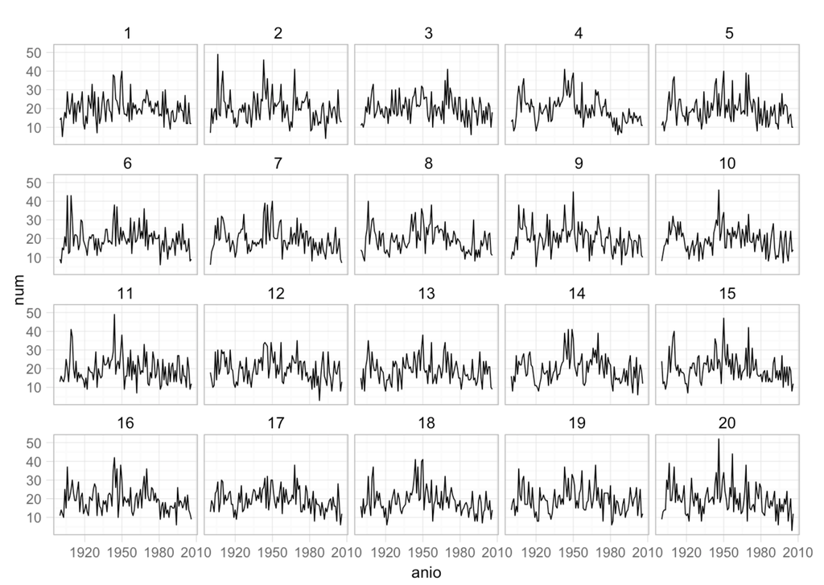

```r
knitr::include_graphics("imagenes/terremotos.png")
```

Simular conjuntos de datos *falsos* puede servir para validar procedimientos estadísticos y para verificar las propiedades de los procesos de estimación.

### 4. Métodos computacionales e inferencia Bayesiana

Imaginemos que nos presentan una moneda y consideramos:

1. La moneda es justa.
2. La moneda sale sol 20% de las veces.
3. La moneda sale sol 80% de las veces.

Pensemos que antes de ver lanzamientos pensamos que cualquiera de estos 3 escenarios es igualmente probable, sin embargo, si vemos 10 lanzamientos y solo 2 soles hace sentido que creamos más fehacientemente en el escenario 2. Veremos exactamente cuánto más creemos en un escenario una vez que observamos datos.

Antes de ver los lanzamientos teníamos ciertas creencias o *creencias a priori* que actualizamos tras ver los lanzamientos para tener *creencias posteriores*.

El objetivo de la inferencia bayesiana es llevarnos de creencias a priori a creencias posteriores, donde nuestras creencias están descritas por distribuciones de probabilidad. Una manera de hacerlo es muestrear una gran cantidad de puntos de la posterior y después, a partir de esos puntos, calcular estadísticas descriptivas de la distribución.

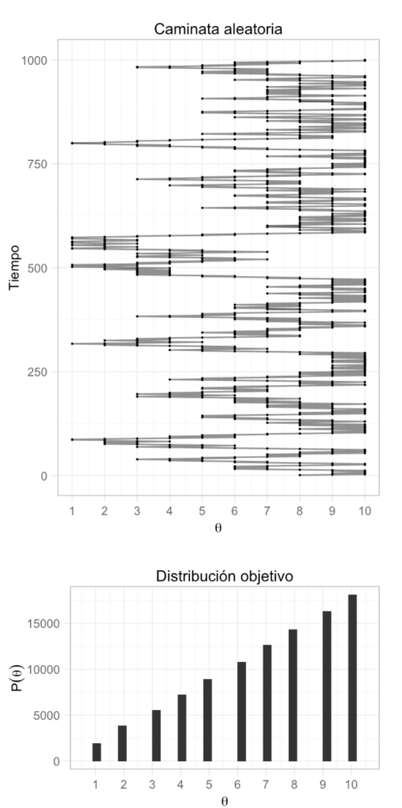

```r
knitr::include_graphics("imagenes/mcmc.png")
```